# Analyse - activité des navires européens et anglais ≥ 25 m pêchant dans les eaux territoriales françaises (hexagone)

Marthe Vienne

2025-05-07

Les figures réalisées lors de cette analyse sont sauvegardées dans le dossier *output*.

## Introduction

L’analyse a été conduite à partir des données statiques d’effort de pêche de Global Fishing Watch (GFW) à l’échelle du navire : https://globalfishingwatch.org/data-download/datasets/public-fishing-effort. La période d’étude s’étend entre 2021 et 2024. L’étude ne concerne que les navires UE + UK ≥ 25 m pêchant dans les eaux territoriales françaises (uniquement en France hexagonale).

Sur la période d’étude, l’historique de la flotte a été construit à partir du registre de la flotte européenne : https://webgate.ec.europa.eu/fleet-europa/search_en. BLOOM a développé son propre gestionnaire du registre de la flotte qui télécharge et synthétise l’historique des navires : https://github.com/associationbloom/eu-fleet-register-manager. Uniquement les navires présents à la fois dans la flotte du registre européen et dans les données GFW ont été retenus.

## Matériel et méthodes

### Zone d’étude

[interactive chart not shown]

### Activité dans les eaux françaises et distribution de la flotte

Le prétraitement des données et construction de la flotte est disponible dans 0.prepare_fishing_activity_data.html

#### Distribution de la flotte pêchant dans les eaux territoriales françaises

##### Distribution de la flotte par pays et par catégorie

| category | BEL | DEU | DNK | ESP | FRA | ITA | NLD | GBR | POL | Total by category |
| --- | --- | --- | --- | --- | --- | --- | --- | --- | --- | --- |
| BOTTOM TRAWLS | 33 | 3 | 2 | 35 | 12 | 13 | 20 | 0 | 0 | 118 |
| GILLNETS AND ENTANGLING NETS | 0 | 0 | 1 | 0 | 11 | 0 | 0 | 0 | 0 | 12 |
| HOOKS AND LINES | 0 | 0 | 0 | 14 | 8 | 0 | 0 | 0 | 0 | 22 |
| LIFT NETS | 0 | 0 | 0 | 0 | 1 | 0 | 0 | 0 | 0 | 1 |
| MIDWATER TRAWLS | 0 | 2 | 0 | 0 | 4 | 0 | 7 | 1 | 1 | 15 |
| SEINE NETS | 1 | 0 | 1 | 0 | 2 | 0 | 12 | 0 | 0 | 16 |
| SURROUNDING NETS | 0 | 0 | 0 | 85 | 7 | 0 | 0 | 0 | 0 | 92 |
| TRAWLS | 0 | 0 | 0 | 0 | 0 | 0 | 3 | 0 | 0 | 3 |
| Total by country | 34 | 5 | 4 | 134 | 45 | 13 | 42 | 1 | 1 | 279 |

##### Distribution de la flotte par pays, par catégorie et par classe de taille

Classes de taille : [25-40), [40-60), [60-80), [80-Inf)

HOOKS AND LINES

| country | [25,40) | Total by country |
| --- | --- | --- |
| ESP | 14 | 14 |
| FRA | 8 | 8 |
| Total by size class | 22 | 22 |

BOTTOM TRAWLS

| country | [25,40) | [80,Inf] | [40,60) | Total by country |
| --- | --- | --- | --- | --- |
| BEL | 36 | 0 | 0 | 36 |
| DEU | 2 | 1 | 0 | 3 |
| DNK | 2 | 0 | 0 | 2 |
| ESP | 34 | 0 | 2 | 36 |
| FRA | 11 | 1 | 2 | 14 |
| ITA | 13 | 0 | 0 | 13 |
| NLD | 12 | 0 | 8 | 20 |
| Total by size class | 110 | 2 | 12 | 124 |

SURROUNDING NETS

| country | [25,40) | [40,60) | Total by country |
| --- | --- | --- | --- |
| ESP | 91 | 0 | 91 |
| FRA | 3 | 6 | 9 |
| Total by size class | 94 | 6 | 100 |

MIDWATER TRAWLS

| country | [80,Inf] | [25,40) | [40,60) | Total by country |
| --- | --- | --- | --- | --- |
| DEU | 2 | 0 | 0 | 2 |
| FRA | 3 | 2 | 0 | 5 |
| GBR | 0 | 0 | 1 | 1 |
| NLD | 6 | 0 | 2 | 8 |
| POL | 1 | 0 | 0 | 1 |
| Total by size class | 12 | 2 | 3 | 17 |

GILLNETS AND ENTANGLING NETS

| country | [25,40) | Total by country |
| --- | --- | --- |
| DNK | 1 | 1 |
| FRA | 12 | 12 |
| Total by size class | 13 | 13 |

SEINE NETS

| country | [25,40) | Total by country |
| --- | --- | --- |
| BEL | 1 | 1 |
| DNK | 1 | 1 |
| FRA | 2 | 2 |
| NLD | 13 | 13 |
| Total by size class | 17 | 17 |

DREDGES

| country | Total by country |
| --- | --- |
| Total by size class | 0 |

TRAWLS

| country | [25,40) | Total by country |
| --- | --- | --- |
| NLD | 3 | 3 |
| Total by size class | 3 | 3 |

TRAPS

| country | Total by country |
| --- | --- |
| Total by size class | 0 |

LIFT NETS

| country | [25,40) | Total by country |
| --- | --- | --- |
| FRA | 1 | 1 |
| Total by size class | 1 | 1 |

## Résultat

### Pourcentage de l’effort de pêche dans les eaux territoriales

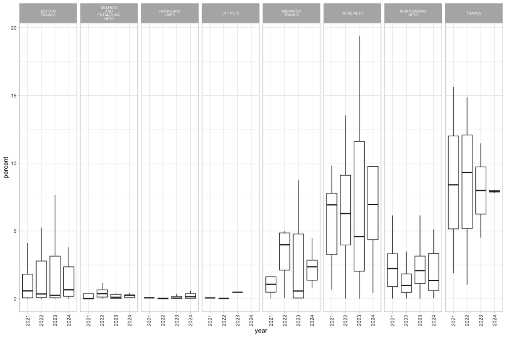

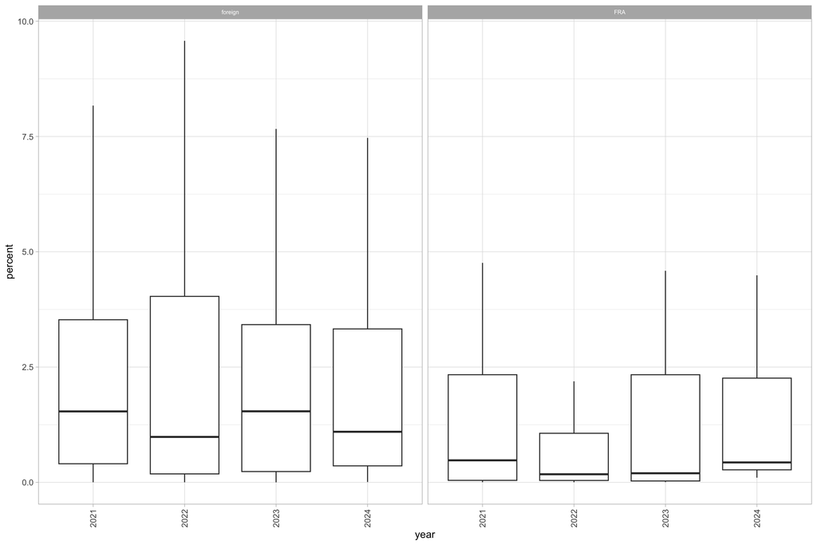

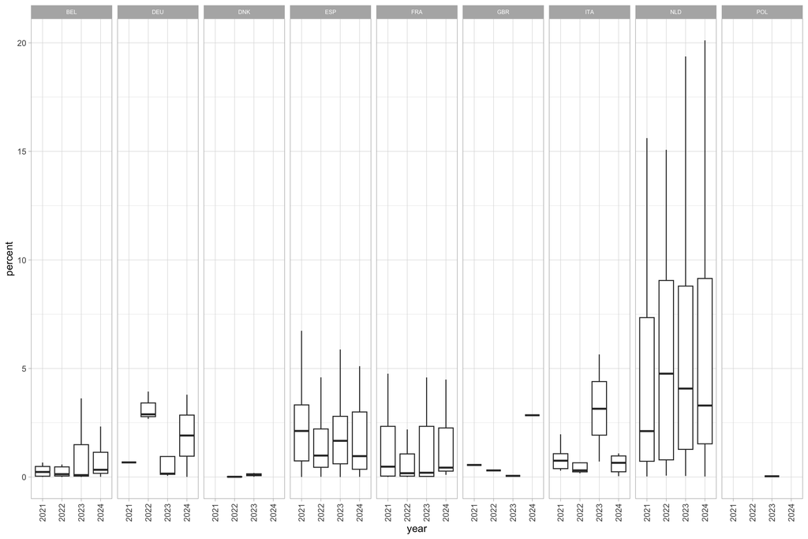

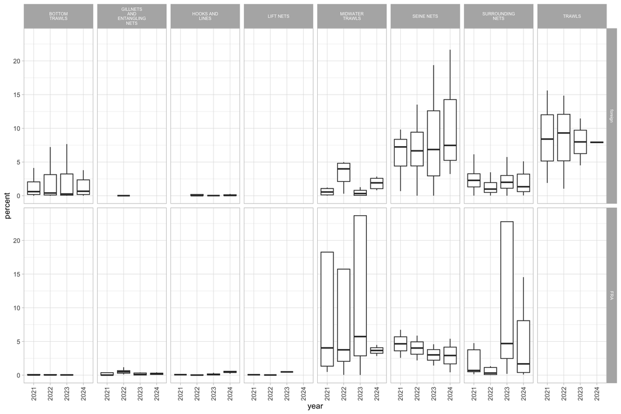

### Résumé statistique

[output not shown]

| category | n | q95 | q75 | q50 | q25 |
| --- | --- | --- | --- | --- | --- |
| MIDWATER TRAWLS | 15 | 23.82 | 3.01 | 1.87 | 0.89 |
| SEINE NETS | 16 | 13.24 | 9.77 | 6.78 | 4.72 |
| TRAWLS | 3 | 10.43 | 8.85 | 6.88 | 5.72 |
| BOTTOM TRAWLS | 118 | 9.93 | 1.20 | 0.40 | 0.09 |
| SURROUNDING NETS | 92 | 4.58 | 2.39 | 1.75 | 1.13 |
| GILLNETS AND ENTANGLING NETS | 12 | 0.62 | 0.40 | 0.28 | 0.10 |
| HOOKS AND LINES | 22 | 0.44 | 0.26 | 0.04 | 0.02 |
| LIFT NETS | 1 | 0.25 | 0.25 | 0.25 | 0.25 |

Pourcentage de l’effort de pêche par an et par pavillon dans les eaux territoriales :

| year | flag | percent |
| --- | --- | --- |
| 2021 | FRA | 3.28 |
| 2021 | foreign | 2.43 |
| 2022 | FRA | 3.25 |
| 2022 | foreign | 2.64 |
| 2023 | FRA | 1.78 |
| 2023 | foreign | 2.04 |
| 2024 | FRA | 1.14 |
| 2024 | foreign | 1.91 |

Résumé de l’effort de pêche total et par an

Sur la période 2021-2024, la flotte a totalisé 33580 heures de pêche dans les eaux territoriales FR (soit 2.3%)

Résumé par an :

| year | total | percent |
| --- | --- | --- |
| 2021 | 6822.27 | 2.60 |
| 2022 | 10958.70 | 2.77 |
| 2023 | 8190.31 | 1.98 |
| 2024 | 7608.24 | 1.81 |

### Cartographie

#### Activité globale et zoom sur les zones de planification maritime française

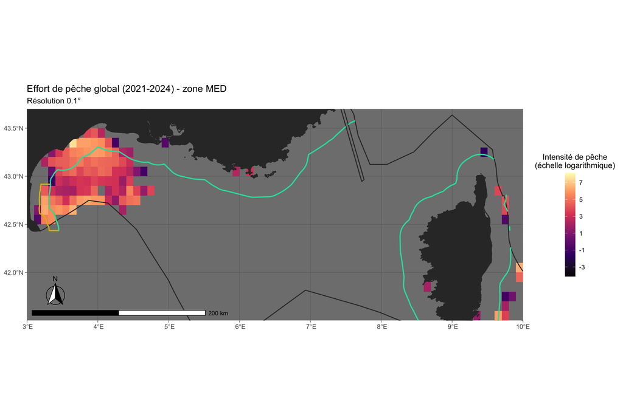

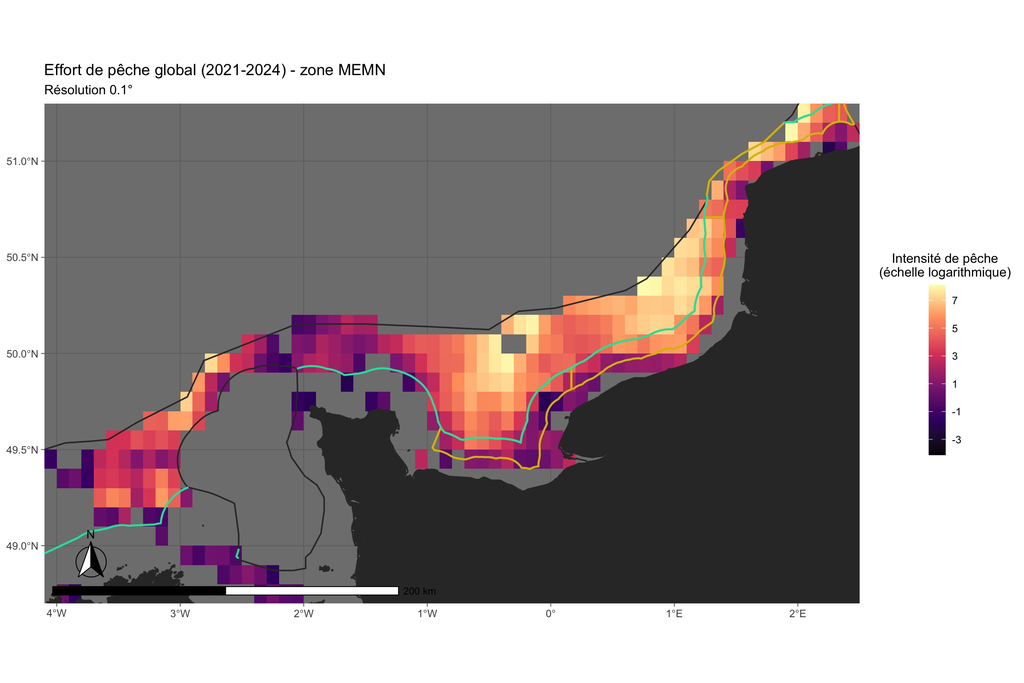

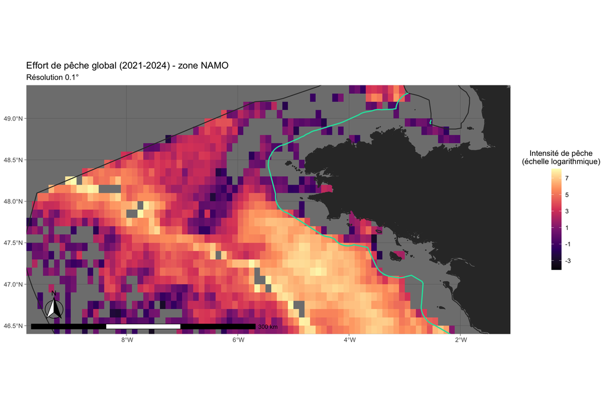

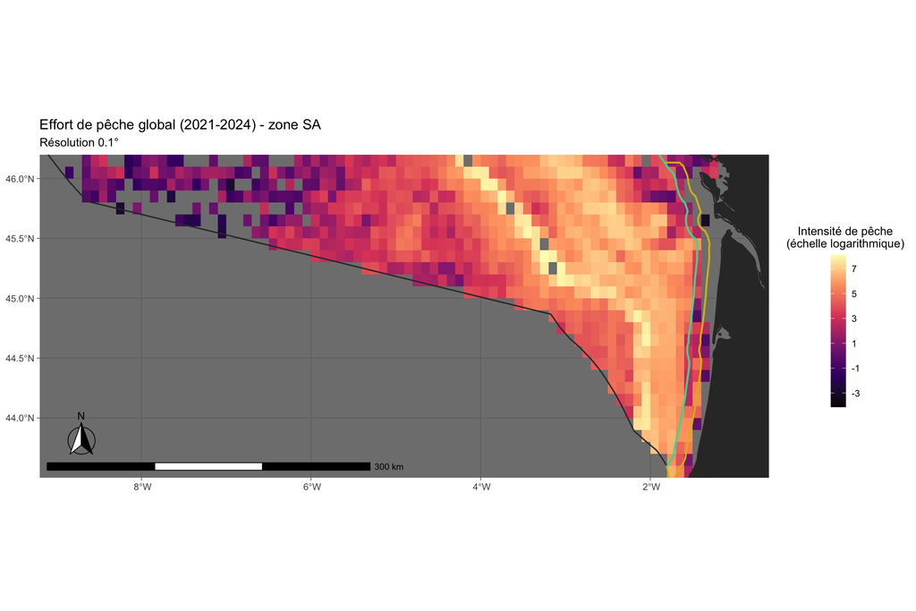